# Homework 3

DATASCI 506

```r
options(scipen = 999)

library(DBI)
library(emmeans)
library(foreign)
library(knitr)
library(microbenchmark)
library(RSQLite)
```

# Problem 1: Audiometry

The NHANES files are SAS transport files, so I use `read.xport()` from the `foreign` package. The records are matched using the respondent sequence number, `SEQN`. Variable definitions and special missing-value codes were checked against the official [AUX_I documentation](https://wwwn.cdc.gov/Nchs/Data/Nhanes/Public/2015/DataFiles/AUX_I.htm) and [DEMO_I documentation](https://wwwn.cdc.gov/Nchs/Data/Nhanes/Public/2015/DataFiles/DEMO_I.htm).

## 1(a) Importing and merging the data

```r
aux <- read.xport("data/AUX_I.XPT")
demo <- read.xport("data/DEMO_I.XPT")

nhanes <- merge(aux, demo, by = "SEQN", all = FALSE)
names(nhanes) <- tolower(names(nhanes))

dim(nhanes)
```

```
[1] 4582  119
```

The inner merge contains 4,582 observations and 119 variables.

## 1(b) Cleaning the analysis variables

Gender is coded 1 for male and 2 for female. Citizenship is coded 1 for citizen and 2 for non-citizen; codes 7 (refused) and 9 (do not know) are set to `NA`. Both variables are converted to factors with informative labels.

`DMDHHSZA` counts children aged 5 or younger. Its value 3 means three or more, but the problem specifically asks that it be used continuously, so it is retained as 3.

The income codes 12 (at or above $20,000) and 13 (below $20,000) overlap the more detailed income ranges, so they cannot be placed on the same continuous scale and are set to `NA`. Codes 77 (refused) and 99 (do not know) are also set to `NA`. Finally, codes 14 ($75,000–$99,999) and 15 ($100,000 or more) are re-coded as 11 and 12 so that the continuous score is correctly ordered.

```r
nhanes$gender <- factor(
  nhanes$riagendr,
  levels = c(1, 2),
  labels = c("Male", "Female")
)

citizenship_clean <- nhanes$dmdcitzn
citizenship_clean[citizenship_clean %in% c(7, 9)] <- NA
nhanes$citizenship <- factor(
  citizenship_clean,
  levels = c(1, 2),
  labels = c("Citizen", "Not a citizen")
)

nhanes$num_children <- nhanes$dmdhhsza

income_score <- nhanes$indhhin2
income_score[income_score %in% c(12, 13, 77, 99)] <- NA
income_score[income_score == 14] <- 11
income_score[income_score == 15] <- 12
nhanes$income_score <- income_score

cleaning_summary <- data.frame(
  variable = c("Gender", "Citizenship", "Number of young children",
               "Household income score", "Right-ear width",
               "Left-ear width"),
  analysis_name = c("gender", "citizenship", "num_children",
                    "income_score", "auxtwidr", "auxtwidl"),
  missing = c(
    sum(is.na(nhanes$gender)),
    sum(is.na(nhanes$citizenship)),
    sum(is.na(nhanes$num_children)),
    sum(is.na(nhanes$income_score)),
    sum(is.na(nhanes$auxtwidr)),
    sum(is.na(nhanes$auxtwidl))
  )
)

kable(cleaning_summary, caption = "Missing values after cleaning")
```

Missing values after cleaning

| variable | analysis_name | missing |
| --- | --- | --- |
| Gender | gender | 0 |
| Citizenship | citizenship | 14 |
| Number of young children | num_children | 0 |
| Household income score | income_score | 495 |
| Right-ear width | auxtwidr | 433 |
| Left-ear width | auxtwidl | 479 |

```r
income_labels <- c(
  "Under $5,000", "$5,000–$9,999", "$10,000–$14,999",
  "$15,000–$19,999", "$20,000–$24,999", "$25,000–$34,999",
  "$35,000–$44,999", "$45,000–$54,999", "$55,000–$64,999",
  "$65,000–$74,999", "$75,000–$99,999", "$100,000 or more"
)

income_distribution <- as.data.frame(table(
  factor(nhanes$income_score, levels = 1:12, labels = income_labels),
  useNA = "ifany"
))
names(income_distribution) <- c("Income category", "Frequency")
kable(income_distribution, caption = "Ordered household-income categories")
```

Ordered household-income categories

| Income category | Frequency |
| --- | --- |
| Under $5,000 | 101 |
| $5,000–$9,999 | 146 |
| $10,000–$14,999 | 233 |
| $15,000–$19,999 | 262 |
| $20,000–$24,999 | 272 |
| $25,000–$34,999 | 461 |
| $35,000–$44,999 | 439 |
| $45,000–$54,999 | 381 |
| $55,000–$64,999 | 295 |
| $65,000–$74,999 | 244 |
| $75,000–$99,999 | 458 |
| $100,000 or more | 795 |
| NA | 495 |

## 1(c) Poisson regression models

I fit the four requested log-link Poisson models. Exponentiating a coefficient produces its incidence rate ratio (IRR). The pseudo-R-squared below is McFadden’s measure, calculated as `1 - logLik(model) / logLik(null model)`.

```r
model_1r <- glm(
  auxtwidr ~ gender,
  data = nhanes,
  family = poisson(link = "log")
)

model_2r <- glm(
  auxtwidr ~ gender + citizenship + num_children + income_score,
  data = nhanes,
  family = poisson(link = "log")
)

model_1l <- glm(
  auxtwidl ~ gender,
  data = nhanes,
  family = poisson(link = "log")
)

model_2l <- glm(
  auxtwidl ~ gender + citizenship + num_children + income_score,
  data = nhanes,
  family = poisson(link = "log")
)

models <- list(`1R` = model_1r, `2R` = model_2r,
               `1L` = model_1l, `2L` = model_2l)
```

```r
coefficient_names <- unique(unlist(lapply(models, function(model) {
  names(coef(model))
})))

irr_table <- data.frame(Term = coefficient_names, check.names = FALSE)

for (model_name in names(models)) {
  model_irr <- exp(coef(models[[model_name]]))
  irr_table[[model_name]] <- model_irr[
    match(coefficient_names, names(model_irr))
  ]
}

term_labels <- c(
  `(Intercept)` = "Intercept",
  genderFemale = "Gender: Female vs. Male",
  `citizenshipNot a citizen` = "Citizenship: Non-citizen vs. citizen",
  num_children = "Number of children age 5 or younger",
  income_score = "Household-income category (one-level increase)"
)
irr_table$Term <- unname(term_labels[irr_table$Term])

kable(
  irr_table,
  digits = 3,
  caption = "Estimated incidence rate ratios for tympanometric width"
)
```

Estimated incidence rate ratios for tympanometric width

| Term | 1R | 2R | 1L | 2L |
| --- | --- | --- | --- | --- |
| Intercept | 84.317 | 88.437 | 84.758 | 88.821 |
| Gender: Female vs. Male | 1.009 | 1.015 | 1.013 | 1.019 |
| Citizenship: Non-citizen vs. citizen | NA | 1.047 | NA | 1.022 |
| Number of children age 5 or younger | NA | 0.994 | NA | 0.983 |
| Household-income category (one-level increase) | NA | 0.992 | NA | 0.993 |

```r
model_statistics <- do.call(
  rbind,
  lapply(names(models), function(model_name) {
    model <- models[[model_name]]
    null_model <- update(model, . ~ 1)
    data.frame(
      Model = model_name,
      Sample_size = nobs(model),
      McFadden_pseudo_R2 = 1 - as.numeric(logLik(model) / logLik(null_model)),
      AIC = AIC(model)
    )
  })
)

kable(
  model_statistics,
  digits = c(0, 0, 4, 1),
  col.names = c("Model", "Sample size", "McFadden pseudo-R²", "AIC"),
  caption = "Poisson model fit statistics"
)
```

Poisson model fit statistics

| Model | Sample size | McFadden pseudo-R² | AIC |
| --- | --- | --- | --- |
| 1R | 4149 | 0.0001 | 96618.5 |
| 2R | 3705 | 0.1213 | 84916.0 |
| 1L | 4103 | 0.0001 | 98685.1 |
| 2L | 3665 | 0.1227 | 86598.0 |

## 1(d) Gender comparisons from model 2L

The model coefficient test compares the left-ear incidence rates for females and males while holding citizenship, number of young children, and income score constant.

```r
gender_coefficient <- coef(summary(model_2l))["genderFemale", ]
gender_irr <- exp(coef(model_2l)["genderFemale"])

gender_test <- data.frame(
  Comparison = "Female vs. Male",
  IRR = unname(gender_irr),
  z_statistic = unname(gender_coefficient["z value"]),
  p_value = format.pval(
    unname(gender_coefficient["Pr(>|z|)"]),
    digits = 3,
    eps = 0.001
  )
)

kable(gender_test, digits = 4, caption = "Gender IRR test from model 2L")
```

Gender IRR test from model 2L

| Comparison | IRR | z_statistic | p_value |
| --- | --- | --- | --- |
| Female vs. Male | 1.0187 | 5.1597 | <0.001 |

The estimated IRR is 1.0187. Thus, after adjustment, the expected left-ear tympanometric width for females is approximately 1.87% higher than for males. The p-value is <0.001, providing strong evidence of a gender difference in the incidence rate.

To compare adjusted predicted values directly, I use estimated marginal means on the response scale. The predictions average over citizenship and use the mean values of the continuous covariates.

```r
gender_predictions <- emmeans(model_2l, ~ gender, type = "response")
prediction_table <- as.data.frame(confint(gender_predictions))
comparison_table <- as.data.frame(pairs(gender_predictions, reverse = TRUE))
comparison_display <- comparison_table[
  , c("contrast", "ratio", "SE", "z.ratio", "p.value")
]
comparison_display$p.value <- format.pval(
  comparison_display$p.value,
  digits = 3,
  eps = 0.001
)

kable(
  prediction_table[, c("gender", "rate", "SE", "asymp.LCL", "asymp.UCL")],
  digits = 3,
  col.names = c("Gender", "Predicted width", "SE", "95% CI lower",
                "95% CI upper"),
  caption = "Adjusted predicted left-ear tympanometric width"
)
```

Adjusted predicted left-ear tympanometric width

| Gender | Predicted width | SE | 95% CI lower | 95% CI upper |
| --- | --- | --- | --- | --- |
| Male | 84.759 | 0.252 | 84.268 | 85.254 |
| Female | 86.348 | 0.249 | 85.862 | 86.838 |

```r
kable(
  comparison_display,
  digits = 4,
  col.names = c("Contrast", "Ratio", "SE", "z statistic", "p-value"),
  caption = "Test of adjusted predicted values"
)
```

Test of adjusted predicted values

| Contrast | Ratio | SE | z statistic | p-value |
| --- | --- | --- | --- | --- |
| Female / Male | 1.0187 | 0.0037 | 5.1597 | <0.001 |

The adjusted predictions are approximately 84.8 for males and 86.3 for females. Their comparison is statistically significant (p <0.001), so the predicted left-ear width differs by gender; females have the larger adjusted prediction.

# Problem 2: Sakila

The SQLite database comes from the specified [Sakila SQLite repository](https://github.com/bradleygrant/sakila-sqlite3). No table with a name ending in `_list` is used. Each task is solved first by extracting tables and working in R, and then by one SQL query.

```r
sakila <- dbConnect(SQLite(), "data/sakila_master.db")
```

## 2(a) Customers and active percentage by store

```r
customers_r <- dbGetQuery(sakila, "SELECT * FROM customer")

store_r <- aggregate(
  as.numeric(customers_r$active),
  by = list(store_id = customers_r$store_id),
  FUN = function(x) c(customers = length(x), active_percent = 100 * mean(x))
)
store_r <- data.frame(
  store_id = store_r$store_id,
  customers = store_r$x[, "customers"],
  active_percent = store_r$x[, "active_percent"]
)

store_sql <- dbGetQuery(sakila, "
  SELECT store_id,
         COUNT(*) AS customers,
         100.0 * AVG(CAST(active AS INTEGER)) AS active_percent
  FROM customer
  GROUP BY store_id
  ORDER BY store_id
")

kable(store_r, digits = 2, caption = "R result: customers by store")
```

R result: customers by store

| store_id | customers | active_percent |
| --- | --- | --- |
| 1 | 326 | 97.55 |
| 2 | 273 | 97.44 |

```r
kable(store_sql, digits = 2, caption = "Single-SQL-query result")
```

Single-SQL-query result

| store_id | customers | active_percent |
| --- | --- | --- |
| 1 | 326 | 97.55 |
| 2 | 273 | 97.44 |

```r
benchmark_2a <- microbenchmark(
  R = {
    customer_b <- dbGetQuery(sakila, "SELECT * FROM customer")
    aggregate(
      as.numeric(customer_b$active),
      by = list(store_id = customer_b$store_id),
      FUN = function(x) c(length(x), 100 * mean(x))
    )
  },
  SQL = {
    dbGetQuery(sakila, "
      SELECT store_id, COUNT(*) AS customers,
             100.0 * AVG(CAST(active AS INTEGER)) AS active_percent
      FROM customer GROUP BY store_id
    ")
  },
  times = 100L
)

kable(
  summary(benchmark_2a, unit = "ms")[, c("expr", "median", "lq", "uq")],
  digits = 3,
  caption = "Benchmark for Problem 2(a), milliseconds"
)
```

Benchmark for Problem 2(a), milliseconds

| expr | median | lq | uq |
| --- | --- | --- | --- |
| R | 0.764 | 0.748 | 0.790 |
| SQL | 0.141 | 0.136 | 0.145 |

## 2(b) Staff names and countries

```r
staff_r <- dbGetQuery(sakila, "SELECT * FROM staff")
address_r <- dbGetQuery(sakila, "SELECT * FROM address")
city_r <- dbGetQuery(sakila, "SELECT * FROM city")
country_r <- dbGetQuery(sakila, "SELECT * FROM country")

staff_location_r <- merge(staff_r, address_r, by = "address_id")
staff_location_r <- merge(staff_location_r, city_r, by = "city_id")
staff_location_r <- merge(staff_location_r, country_r, by = "country_id")
staff_result_r <- staff_location_r[
  order(staff_location_r$staff_id),
  c("first_name", "last_name", "country")
]

staff_result_sql <- dbGetQuery(sakila, "
  SELECT s.first_name, s.last_name, co.country
  FROM staff AS s
  JOIN address AS a ON s.address_id = a.address_id
  JOIN city AS ci ON a.city_id = ci.city_id
  JOIN country AS co ON ci.country_id = co.country_id
  ORDER BY s.staff_id
")

kable(staff_result_r, caption = "R result: staff members and countries")
```

R result: staff members and countries

|  | first_name | last_name | country |
| --- | --- | --- | --- |
| 2 | Mike | Hillyer | Canada |
| 1 | Jon | Stephens | Australia |

```r
kable(staff_result_sql, caption = "Single-SQL-query result")
```

Single-SQL-query result

| first_name | last_name | country |
| --- | --- | --- |
| Mike | Hillyer | Canada |
| Jon | Stephens | Australia |

```r
benchmark_2b <- microbenchmark(
  R = {
    s <- dbGetQuery(sakila, "SELECT * FROM staff")
    a <- dbGetQuery(sakila, "SELECT * FROM address")
    ci <- dbGetQuery(sakila, "SELECT * FROM city")
    co <- dbGetQuery(sakila, "SELECT * FROM country")
    temp <- merge(s, a, by = "address_id")
    temp <- merge(temp, ci, by = "city_id")
    temp <- merge(temp, co, by = "country_id")
    temp[, c("first_name", "last_name", "country")]
  },
  SQL = {
    dbGetQuery(sakila, "
      SELECT s.first_name, s.last_name, co.country
      FROM staff AS s
      JOIN address AS a ON s.address_id = a.address_id
      JOIN city AS ci ON a.city_id = ci.city_id
      JOIN country AS co ON ci.country_id = co.country_id
    ")
  },
  times = 100L
)

kable(
  summary(benchmark_2b, unit = "ms")[, c("expr", "median", "lq", "uq")],
  digits = 3,
  caption = "Benchmark for Problem 2(b), milliseconds"
)
```

Benchmark for Problem 2(b), milliseconds

| expr | median | lq | uq |
| --- | --- | --- | --- |
| R | 1.576 | 1.531 | 1.647 |
| SQL | 0.091 | 0.086 | 0.097 |

## 2(c) Films rented for the highest dollar value

```r
payment_r <- dbGetQuery(sakila, "SELECT * FROM payment")
rental_r <- dbGetQuery(sakila, "SELECT * FROM rental")
inventory_r <- dbGetQuery(sakila, "SELECT * FROM inventory")
film_r <- dbGetQuery(sakila, "SELECT * FROM film")

highest_payments <- payment_r[
  payment_r$amount == max(payment_r$amount),
  c("rental_id", "amount")
]
film_payment_r <- merge(highest_payments, rental_r, by = "rental_id")
film_payment_r <- merge(film_payment_r, inventory_r, by = "inventory_id")
film_payment_r <- merge(film_payment_r, film_r, by = "film_id")
highest_films_r <- unique(film_payment_r[c("title", "amount")])
highest_films_r <- highest_films_r[order(highest_films_r$title), ]

highest_films_sql <- dbGetQuery(sakila, "
  SELECT DISTINCT f.title, p.amount
  FROM payment AS p
  JOIN rental AS r ON p.rental_id = r.rental_id
  JOIN inventory AS i ON r.inventory_id = i.inventory_id
  JOIN film AS f ON i.film_id = f.film_id
  WHERE p.amount = (SELECT MAX(amount) FROM payment)
  ORDER BY f.title
")

kable(highest_films_r, digits = 2,
      caption = "R result: films with the highest rental payment")
```

R result: films with the highest rental payment

|  | title | amount |
| --- | --- | --- |
| 1 | FLINTSTONES HAPPINESS | 11.99 |
| 2 | MIDSUMMER GROUNDHOG | 11.99 |
| 3 | MINE TITANS | 11.99 |
| 4 | SCORPION APOLLO | 11.99 |
| 6 | SHOW LORD | 11.99 |
| 7 | STING PERSONAL | 11.99 |
| 8 | TIES HUNGER | 11.99 |
| 9 | TRAP GUYS | 11.99 |
| 10 | VIRTUAL SPOILERS | 11.99 |

```r
kable(highest_films_sql, digits = 2,
      caption = "Single-SQL-query result")
```

Single-SQL-query result

| title | amount |
| --- | --- |
| FLINTSTONES HAPPINESS | 11.99 |
| MIDSUMMER GROUNDHOG | 11.99 |
| MINE TITANS | 11.99 |
| SCORPION APOLLO | 11.99 |
| SHOW LORD | 11.99 |
| STING PERSONAL | 11.99 |
| TIES HUNGER | 11.99 |
| TRAP GUYS | 11.99 |
| VIRTUAL SPOILERS | 11.99 |

The maximum payment is $11.99, and 9 distinct films were rented at this value.

```r
benchmark_2c <- microbenchmark(
  R = {
    p <- dbGetQuery(sakila, "SELECT * FROM payment")
    r <- dbGetQuery(sakila, "SELECT * FROM rental")
    i <- dbGetQuery(sakila, "SELECT * FROM inventory")
    f <- dbGetQuery(sakila, "SELECT * FROM film")
    top <- p[p$amount == max(p$amount), c("rental_id", "amount")]
    temp <- merge(top, r, by = "rental_id")
    temp <- merge(temp, i, by = "inventory_id")
    temp <- merge(temp, f, by = "film_id")
    unique(temp[c("title", "amount")])
  },
  SQL = {
    dbGetQuery(sakila, "
      SELECT DISTINCT f.title, p.amount
      FROM payment AS p
      JOIN rental AS r ON p.rental_id = r.rental_id
      JOIN inventory AS i ON r.inventory_id = i.inventory_id
      JOIN film AS f ON i.film_id = f.film_id
      WHERE p.amount = (SELECT MAX(amount) FROM payment)
    ")
  },
  times = 100L
)

kable(
  summary(benchmark_2c, unit = "ms")[, c("expr", "median", "lq", "uq")],
  digits = 3,
  caption = "Benchmark for Problem 2(c), milliseconds"
)
```

Benchmark for Problem 2(c), milliseconds

| expr | median | lq | uq |
| --- | --- | --- | --- |
| R | 22.470 | 21.969 | 23.044 |
| SQL | 0.767 | 0.718 | 1.168 |

Across all three comparisons, the single SQL query is expected to be faster because SQLite performs filtering, aggregation, and joins internally and returns only the small final result. The R approach transfers entire tables and then performs additional work in R. The benchmark tables quantify this difference on the computer used to render this document.

```r
dbDisconnect(sakila)
```

# Problem 3: Australian Records

The data were downloaded from Brian Dunning’s [Free Sample Data](https://www.briandunning.com/sample-data/) page. The site states that these are fake records created for database testing.

```r
australia <- read.csv("data/au-500.csv", stringsAsFactors = FALSE)
```

## 3(a) Websites ending in `.com`

```r
percent_dot_com <- 100 * mean(grepl("\\.com$", australia$web,
                                    ignore.case = TRUE))
percent_dot_com
```

```
[1] 0
```

0% of the websites end in `.com`. The end anchor (`$`) is important: a search for `.com` anywhere would incorrectly include `.com.au`.

## 3(b) Most common email domain

```r
email_domains <- sub("^.*@", "", australia$email)
domain_counts <- sort(table(email_domains), decreasing = TRUE)

data.frame(
  domain = names(domain_counts)[1],
  frequency = as.integer(domain_counts[1]),
  percentage = 100 * as.integer(domain_counts[1]) / nrow(australia)
) |>
  kable(digits = 1, caption = "Most common email domain")
```

Most common email domain

| domain | frequency | percentage |
| --- | --- | --- |
| hotmail.com | 114 | 22.8 |

The most common domain is hotmail.com, appearing 114 times.

## 3(c) Non-alphabetic characters in company names

```r
nonalpha_excluding_comma_space <- grepl(
  "[^[:alpha:],[:space:]]",
  australia$company_name
)
nonalpha_excluding_comma_space_ampersand <- grepl(
  "[^[:alpha:],&[:space:]]",
  australia$company_name
)

company_character_results <- data.frame(
  Rule = c(
    "Exclude commas and whitespace",
    "Exclude commas, whitespace, and ampersands"
  ),
  Proportion = c(
    mean(nonalpha_excluding_comma_space),
    mean(nonalpha_excluding_comma_space_ampersand)
  ),
  Percentage = 100 * c(
    mean(nonalpha_excluding_comma_space),
    mean(nonalpha_excluding_comma_space_ampersand)
  )
)

kable(company_character_results, digits = 3,
      caption = "Company names containing an eligible non-alphabetic character")
```

Company names containing an eligible non-alphabetic character

| Rule | Proportion | Percentage |
| --- | --- | --- |
| Exclude commas and whitespace | 0.090 | 9.0 |
| Exclude commas, whitespace, and ampersands | 0.008 | 0.8 |

The proportions are 0.09 (9%) when commas and whitespace are excluded, and 0.008 (0.8%) when ampersands are also excluded.

## 3(d) Standardizing phone numbers

The following function removes every non-digit character, verifies that ten digits remain, and inserts hyphens after the fourth and seventh digits.

```r
#' Convert an Australian phone number to XXXX-XXX-XXX format.
#'
#' @param phone A character vector of phone numbers.
#' @return A character vector in cell-phone format; invalid inputs become NA.
format_au_phone <- function(phone) {
  digits <- gsub("[^0-9]", "", phone)
  valid <- nchar(digits) == 10
  output <- rep(NA_character_, length(phone))
  output[valid] <- paste0(
    substr(digits[valid], 1, 4), "-",
    substr(digits[valid], 5, 7), "-",
    substr(digits[valid], 8, 10)
  )
  output
}

australia$phone1 <- format_au_phone(australia$phone1)
australia$phone2 <- format_au_phone(australia$phone2)

kable(
  head(australia[c("phone1", "phone2")], 10),
  caption = "First ten standardized phone numbers"
)
```

First ten standardized phone numbers

| phone1 | phone2 |
| --- | --- |
| 0381-749-123 | 0458-665-290 |
| 0799-973-366 | 0497-622-620 |
| 0855-589-019 | 0427-885-282 |
| 0260-444-682 | 0443-795-912 |
| 0214-556-085 | 0453-666-885 |
| 0878-681-355 | 0451-966-921 |
| 0865-228-931 | 0427-991-688 |
| 0252-269-402 | 0415-961-606 |
| 0731-849-989 | 0411-732-965 |
| 0868-904-661 | 0461-862-457 |

Both columns now match the required `XXXX-XXX-XXX` pattern:

```r
all(grepl("^[0-9]{4}-[0-9]{3}-[0-9]{3}$", australia$phone1))
```

```
[1] TRUE
```

```r
all(grepl("^[0-9]{4}-[0-9]{3}-[0-9]{3}$", australia$phone2))
```

```
[1] TRUE
```

## 3(e) Log apartment-number histogram

Following the instruction, any digits at the end of an address are treated as an apartment number.

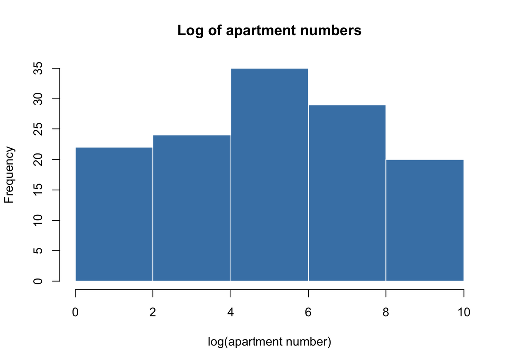

```r
apartment_text <- regmatches(
  australia$address,
  regexpr("[0-9]+$", australia$address)
)
apartment_numbers <- as.numeric(apartment_text[nzchar(apartment_text)])

hist(
  log(apartment_numbers),
  breaks = "FD",
  col = "steelblue",
  border = "white",
  main = "Log of apartment numbers",
  xlab = "log(apartment number)"
)
```

There are 130 addresses ending in a number and hence included in the histogram.

## 3(f) Benford’s law

Under Benford’s law, the probability of leading digit `d` is `log10(1 + 1/d)`. I compare the observed distribution with these probabilities and perform a chi-squared goodness-of-fit test.

```r
leading_digits <- as.integer(substr(as.character(apartment_numbers), 1, 1))
observed <- table(factor(leading_digits, levels = 1:9))
benford_probability <- log10(1 + 1 / (1:9))
benford_test <- chisq.test(observed, p = benford_probability)

benford_table <- data.frame(
  Leading_digit = 1:9,
  Observed_count = as.integer(observed),
  Observed_percent = 100 * as.integer(observed) / sum(observed),
  Benford_expected_percent = 100 * benford_probability
)

kable(benford_table, digits = 1,
      caption = "Observed leading digits versus Benford's law")
```

Observed leading digits versus Benford’s law

| Leading_digit | Observed_count | Observed_percent | Benford_expected_percent |
| --- | --- | --- | --- |
| 1 | 12 | 9.2 | 30.1 |
| 2 | 19 | 14.6 | 17.6 |
| 3 | 16 | 12.3 | 12.5 |
| 4 | 13 | 10.0 | 9.7 |
| 5 | 14 | 10.8 | 7.9 |
| 6 | 18 | 13.8 | 6.7 |
| 7 | 8 | 6.2 | 5.8 |
| 8 | 11 | 8.5 | 5.1 |
| 9 | 19 | 14.6 | 4.6 |

```r
benford_test_table <- data.frame(
  chi_squared = unname(benford_test$statistic),
  degrees_of_freedom = unname(benford_test$parameter),
  p_value = format.pval(benford_test$p.value, digits = 3, eps = 0.0001)
)

kable(benford_test_table, digits = 4,
      caption = "Benford goodness-of-fit test")
```

Benford goodness-of-fit test

| chi_squared | degrees_of_freedom | p_value |
| --- | --- | --- |
| 62.2678 | 8 | <0.0001 |

The observed leading digits are much closer to a uniform distribution than to Benford’s strongly decreasing distribution. The goodness-of-fit p-value is <0.0001, giving strong evidence against Benford’s law. Therefore, the apartment numbers would not pass as realistic Benford-distributed data.

# Sources

- CDC/NCHS, [NHANES 2015–2016 Audiometry documentation](https://wwwn.cdc.gov/Nchs/Data/Nhanes/Public/2015/DataFiles/AUX_I.htm).
- CDC/NCHS, [NHANES 2015–2016 Demographic Variables documentation](https://wwwn.cdc.gov/Nchs/Data/Nhanes/Public/2015/DataFiles/DEMO_I.htm).
- Bradley Grant, [Sakila SQLite database](https://github.com/bradleygrant/sakila-sqlite3).
- Brian Dunning, [Free Sample Data](https://www.briandunning.com/sample-data/).